### Assignment 9

I am using the Grad school Admissions data set to investigate the impact of various variables on admission acceptance.

Here are the packages I am using.

```r
library(tidyverse)
library(easystats)
library(tidymodels)
```

Lets take a glimpse at the structure of our data.

```r
head(dat)
```

```
## # A tibble: 6 × 4
##   admit   gre   gpa  rank
##   <dbl> <dbl> <dbl> <dbl>
## 1     0   380  3.61     3
## 2     1   660  3.67     3
## 3     1   800  4        1
## 4     1   640  3.19     4
## 5     0   520  2.93     4
## 6     1   760  3        2
```

Above we see that our data consists of four variables…

- admit: The students admission status (0 = rejected, 1 = accepted)
- gre: GRE score (ranging from 220 - 800)
- gpa: GPA (ranging from 2.26 - 4.00)
- rank: The rating of the students undergrad institution (1 being the best, 4 being the worst)

Now, lets visualize the data:

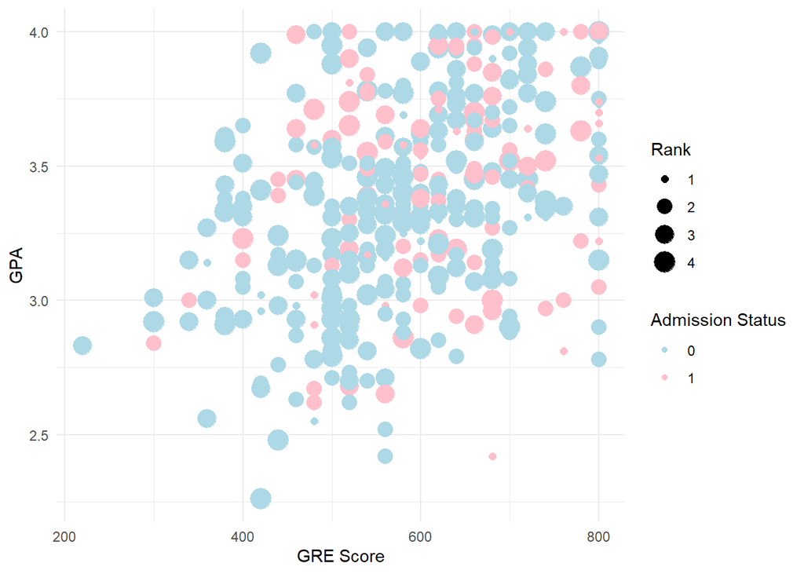

```r
ggplot(dat, aes(x = gre, y = gpa, color = as.factor(admit), size = rank)) +
  geom_point() +
  labs(x = "GRE Score", y = "GPA", color = "Admission Status", size = "Rank") +
  scale_color_manual(values = c("lightblue", "pink")) +
  scale_size_continuous(range = c(2, 6)) +
  theme_minimal()
```

From the plot, it appears that as GPA and GRE are positively correlated. Rank and admission status is harder to explore.

Lets look at the amount of students that were accepted (1) vs rejected (0), and the amount of students who attended each school rank (1-4).

```r
table(dat$admit)
```

```
##
##   0   1
## 273 127
```

```r
table(dat$rank)
```

```
##
##   1   2   3   4
##  61 151 121  67
```

Next, I’ll create three models of varying complexity.

```r
mod1 <- glm(data = dat,
            formula = as.logical(admit) ~ rank,
            family = "binomial")

mod2 <- glm(data = dat,
            formula = as.logical(admit) ~ gpa + gre,
            family = "binomial")

mod3 <- glm(data = dat,
            formula = as.logical(admit) ~ gpa * gre * rank,
            family = "binomial")
```

- Model 1 predicts admission based on rank
- Model 2 uses gpa and gre for prediction
- Model 3 includes interactions between gpa, gre, and rank

Lets look at how they did…

```r
performance_mod1
```

```
## [1] 0.695
```

```r
performance_mod2
```

```
## [1] 0.68
```

```r
performance_mod3
```

```
## [1] 0.7075
```

It seems that Model 3 had the highest accuracy at 70.75%, followed by Model 1 (69.50%), and Model 2 (68.00%).

```r
prediction_counts
```

```
##              Model  X0 X1
## outcome_mod1  mod1 339 61
## outcome_mod2  mod2 381 19
## outcome_mod3  mod3 354 46
```

They all predicted more students being rejected rather than accepted, so I guess that is good. Lets go ahead and compare the statistics.

```r
compare_performance(mod1, mod2, mod3, rank = TRUE)
```

```
## # Comparison of Model Performance Indices
##
## Name | Model | Tjur's R2 |  RMSE | Sigma | Log_loss | Score_log | Score_spherical |   PCP | AIC weights | AICc weights | BIC weights | Performance-Score
## --------------------------------------------------------------------------------------------------------------------------------------------------------
## mod3 |   glm |     0.106 | 0.440 | 1.000 |    0.570 |   -50.593 |           0.005 | 0.613 |       0.976 |        0.971 |    2.62e-04 |            56.62%
## mod1 |   glm |     0.060 | 0.451 | 1.000 |    0.595 |   -49.032 |           0.010 | 0.593 |       0.023 |        0.028 |       0.995 |            48.56%
## mod2 |   glm |     0.047 | 0.455 | 1.000 |    0.600 |   -48.679 |           0.004 | 0.587 |    8.49e-04 |     9.86e-04 |       0.005 |            22.27%
```

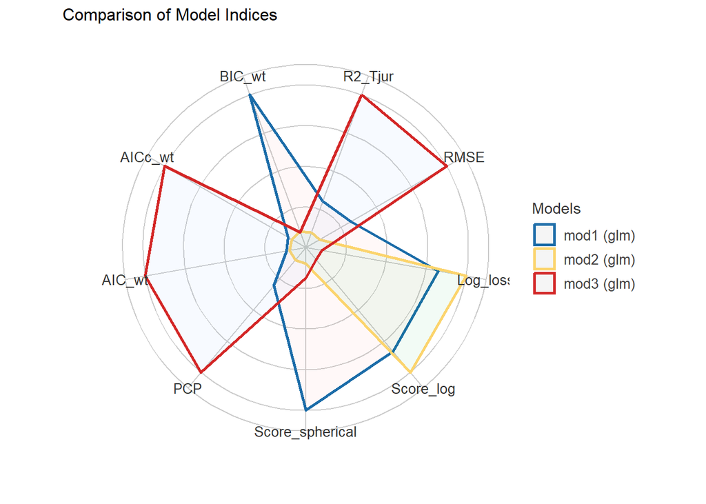

```r
compare_performance(mod1, mod2, mod3, rank = TRUE) %>% plot
```

Looking at the R-squared, RMSE, and AIC, it is clear that Model 3 outperforms the other two. It seems that model 3 is our best fit.

But wait! These models were tested on data they had already seen D:

Time to retrain the models…

```r
set.seed(0)
split <- initial_split(dat, prop = 0.7)
training_dat <- training(split)
test_dat <- testing(split)

mod1 <- glm(data = training_dat,
            formula = as.logical(admit) ~ rank,
            family = "binomial")

mod2 <- glm(data = training_dat,
            formula = as.logical(admit) ~ gpa + gre,
            family = "binomial")

mod3 <- glm(data = training_dat,
            formula = as.logical(admit) ~ gpa * gre * rank,
            family = "binomial")
```

The model formulas remained the same, but they were trained on 70% of the data. The remaining 30% we will use to test the models predictions. The seed was set for reproducibility.

Now lets look at the predictions again, this time using test data that the models have not seen.

```r
performance_mod1
```

```
## [1] 0.7166667
```

```r
performance_mod2
```

```
## [1] 0.675
```

```r
performance_mod3
```

```
## [1] 0.7166667
```

Interesting, it looks like model 2 performed slightly worse while the other two models did slightly better. Lets look more at Model 3.

```r
mod3 %>% model_parameters()
```

```
## Parameter          | Log-Odds |       SE |          95% CI |     z |     p
## --------------------------------------------------------------------------
## (Intercept)        |   -28.87 |    18.48 | [-65.77,  7.05] | -1.56 | 0.118
## gpa                |     8.84 |     5.55 | [ -1.92, 19.94] |  1.59 | 0.111
## gre                |     0.04 |     0.03 | [ -0.02,  0.10] |  1.44 | 0.151
## rank               |     7.76 |     7.56 | [ -7.53, 22.10] |  1.03 | 0.305
## gpa × gre          |    -0.01 | 8.91e-03 | [ -0.03,  0.00] | -1.44 | 0.150
## gpa × rank         |    -2.66 |     2.25 | [ -6.96,  1.84] | -1.19 | 0.235
## gre × rank         |    -0.01 |     0.01 | [ -0.04,  0.01] | -1.11 | 0.268
## (gpa × gre) × rank | 4.40e-03 | 3.70e-03 | [ -0.00,  0.01] |  1.19 | 0.233
```

The analysis suggests that GPA, GRE, and rank individually could influence grad school admission. However, the lack of significant p-values and high standard errors indicates uncertainty in most cases.

Further investigation and model refinement is needed to create a more accurate model for predicting grad school admission.